# 360 project

2022-06-06

```r
# code is hidden initially
```

# IE 360 Spring 2022 Project

## Intoduction

The main aim of this project is forecasting hourly solar power KIVANC 2 Solar Power Central from 24 May 2022 to 3 June by developing models and making statistical analysis based on the available data. The data that is used in project consist of hourly temparature, relative humidity, downward shortwave radiation and cloud cover for the 9 different coordinates related to solar plants’ locations and hourly production of solar power central. The models that are developed for the forecasting uses the available data (at day d data until day d-1 is available and forecast for day d+1 is done based on available data) and ma ke forecasts which consist of 24 predictions (hourly predictions) for the next day. Before model developing process the data is analyzed visually to determine what kind of models can be useful and develop a better understanding on the data.

```r
require(data.table)
require(lubridate)
require(zoo)
library(forecast)
library(tseries)
library(ggplot2)
require(urca)
library(GGally)
data_path="C:/Users/dogad/Desktop/IE360/proje/2022-06-06_production.csv"
production = fread(data_path)
production[,date:=as.Date(date)]

data_path2="C:/Users/dogad/Desktop/IE360/proje/2022-06-06_weather.csv"
l_weather = fread(data_path2)
l_weather[,date:=as.Date(date)]
w_weather=dcast(l_weather,date+hour~variable+lat+lon,value.var="value")
w_weather$month=as.numeric(format(w_weather$date,format="%m"))

data=merge(production,w_weather,by=c("date","hour"))
data$month=as.numeric(format(data$date,format="%m"))

train_start=as.Date('2021-03-31')
test_start= as.Date('2022-03-01')
test_end = as.Date('2022-05-24')
current_date= "2022-06-02"
```

###Hourly Production Plots

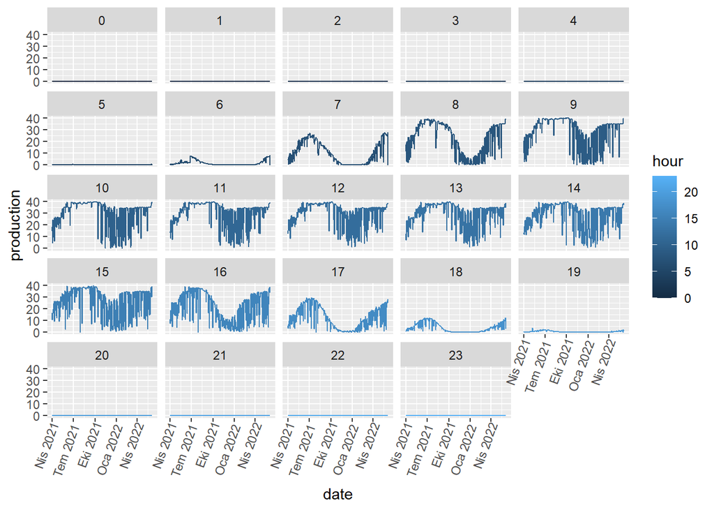

```r
ggplot(data[date>=train_start],aes(x=date,y=production,col=hour))+geom_line()+facet_wrap(~hour)+theme(axis.text.x=element_text(angle=70, hjust=1.4, vjust = 1.4))
```

It is seen that there is no production between 20.00 pm and 6.00 am. There is a decrease in production for every hours in winter which indicates that there is a seasonal behaviour due to changes in the day times at different seasons.

###Daily Production

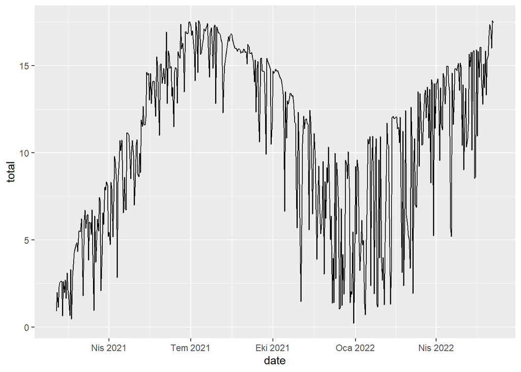

```r
daily_series=data[,list(total=mean(production)),list(date)]
ggplot(daily_series,aes(x=date,y=total))+geom_line()
```

Daily production of solar plants are plotted to obtain general information about the data such as the production capacity of the plants and variation. The variation in February 2021-June 2021 is less than February 2022-June 2022. Moreover, in 2021 the production is less than in 2022 for some months. For example in April 2021 the production is approximately between 5-10 but in April 2022 the values are between 5-15. An explanation for this situation can be the plants may not have used their 100 % capacity. Therefore some of the data can be cut off to obtain a data with more stable variance and a smoother model.

###Autocorrelation of Hourly Production

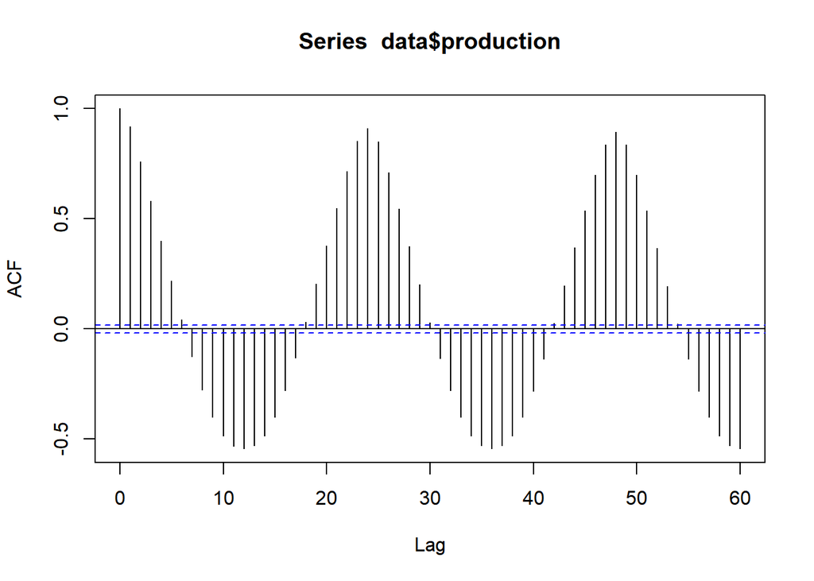

```r
acf(data$production,lag.max = 60)
```

###Partial Autocorrelation of Hourly Production

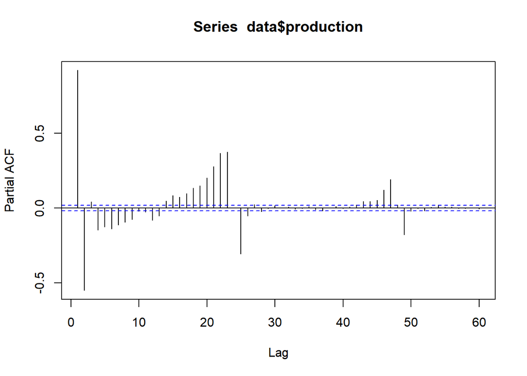

```r
pacf(data$production,lag.max = 60)
```

##Approaches

###1) Linear Regression and Time Series Regressions Since data has a seasonal behaviour (hourly-monthly-seasonally), using weather data with time-related regressors can be good approach. Models built step by step (by adding regressors) and their performances measured based on adjusted R squared and residual plots. In addition, since the weather data has too many rows, the data is averaged over 9 coordinates and a ggpairs plot is made to analyze regressors better. These models are built to forecast 07.00-19.00 because there is no significant production before 07.00 and after 19.00, the forecasts for these hours are zero. Therefore there is no need to build a model to predict those hours.

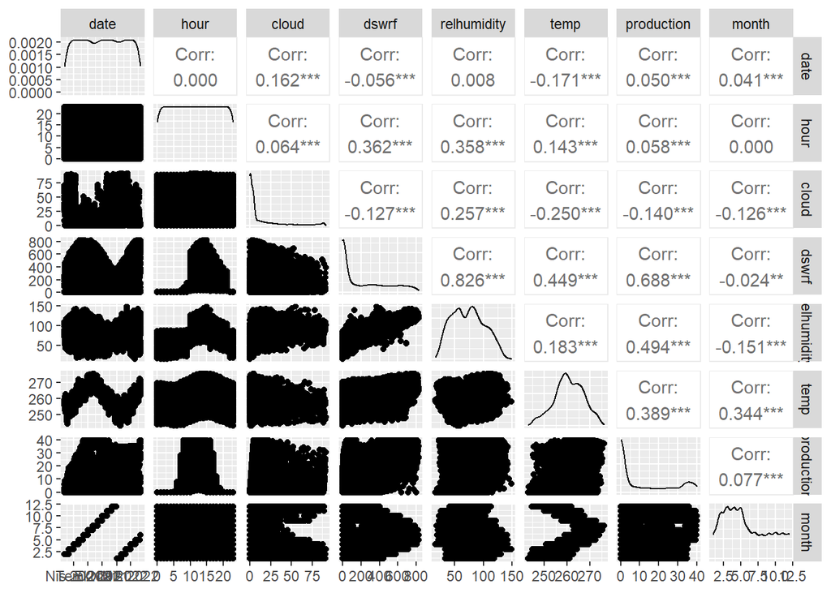

```r
avgdata=data.table(date=data$date,hour=data$hour,cloud=rowSums(data[,3:11])/9,dswrf=rowSums(data[,12:20])/9,relhumidity=rowSums(data[,21:29])/9,temp=rowSums(data[,30:38])/9,production=data$production,month=as.numeric(format(data$date,format="%m")))
avgweather=data.table(date=w_weather$date,hour=w_weather$hour,cloud=rowSums(data[,3:11])/9,dswrf=rowSums(data[,12:20])/9,relhumidity=rowSums(data[,21:29])/9,temp=rowSums(data[,30:38])/9)
model_avg = lm(production~.-date-hour-month-production,avgdata[hour>=7 & hour <=18])
ggpairs(avgdata)
```

###a) Model with only averaged data

```r
summary(model_avg)
```

```
##
## Call:
## lm(formula = production ~ . - date - hour - month - production,
##     data = avgdata[hour >= 7 & hour <= 18])
##
## Residuals:
##     Min      1Q  Median      3Q     Max
## -35.929  -8.201   0.634   8.400  24.992
##
## Coefficients:
##               Estimate Std. Error t value Pr(>|t|)
## (Intercept) -64.549581   7.325708  -8.811  < 2e-16 ***
## cloud        -0.046586   0.009048  -5.149 2.71e-07 ***
## dswrf         0.037309   0.001586  23.527  < 2e-16 ***
## relhumidity  -0.215644   0.013993 -15.410  < 2e-16 ***
## temp          0.349606   0.027372  12.772  < 2e-16 ***
## ---
## Signif. codes:  0 '***' 0.001 '**' 0.01 '*' 0.05 '.' 0.1 ' ' 1
##
## Residual standard error: 11.05 on 5791 degrees of freedom
## Multiple R-squared:  0.362,  Adjusted R-squared:  0.3615
## F-statistic: 821.3 on 4 and 5791 DF,  p-value: < 2.2e-16
```

####Residual plots of the only averaged data model

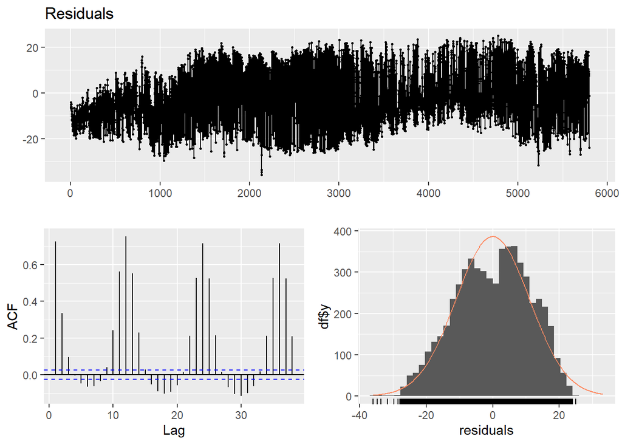

```
##
##  Breusch-Godfrey test for serial correlation of order up to 10
##
## data:  Residuals
## LM test = 4003, df = 10, p-value < 2.2e-16
```

```r
checkresiduals(model_avg)
```

Although all of the regressors are significant and are correlated with the production which can be seen in ggpairs plot (correlation matrix), these regressors are not enough to explain the model just by themselves. Residuals are highly correlated due to seasonal behaivour of the data which has already been observed in introduction part. Therefore month and hour information is added to obtain a better model.

###b) Model with averaged data + time related regressors (hour and month)

```r
model_avg_time = lm(production~.-date-hour-month+as.factor(month)+as.factor(hour)-production,avgdata[hour>=7 & hour <=18])
summary(model_avg_time) #hour and month added
```

```
##
## Call:
## lm(formula = production ~ . - date - hour - month + as.factor(month) +
##     as.factor(hour) - production, data = avgdata[hour >= 7 &
##     hour <= 18])
##
## Residuals:
##     Min      1Q  Median      3Q     Max
## -37.558  -5.080   0.198   5.363  24.024
##
## Coefficients:
##                     Estimate Std. Error t value Pr(>|t|)
## (Intercept)        79.774600   8.391547   9.507  < 2e-16 ***
## cloud              -0.064654   0.006928  -9.333  < 2e-16 ***
## dswrf               0.019941   0.001586  12.576  < 2e-16 ***
## relhumidity        -0.106615   0.010576 -10.081  < 2e-16 ***
## temp               -0.271094   0.033497  -8.093 7.03e-16 ***
## as.factor(month)2  -2.708314   0.517059  -5.238 1.68e-07 ***
## as.factor(month)3   0.793581   0.530000   1.497  0.13436
## as.factor(month)4   4.389223   0.653746   6.714 2.08e-11 ***
## as.factor(month)5   9.378710   0.751077  12.487  < 2e-16 ***
## as.factor(month)6  14.294819   0.837547  17.067  < 2e-16 ***
## as.factor(month)7  16.521819   0.924164  17.878  < 2e-16 ***
## as.factor(month)8  15.726162   0.928121  16.944  < 2e-16 ***
## as.factor(month)9  13.050985   0.794215  16.433  < 2e-16 ***
## as.factor(month)10  8.545323   0.692813  12.334  < 2e-16 ***
## as.factor(month)11  2.697332   0.635111   4.247 2.20e-05 ***
## as.factor(month)12 -1.638207   0.572348  -2.862  0.00422 **
## as.factor(hour)8   11.333631   0.490113  23.125  < 2e-16 ***
## as.factor(hour)9   16.665178   0.502715  33.150  < 2e-16 ***
## as.factor(hour)10  15.909003   0.693660  22.935  < 2e-16 ***
## as.factor(hour)11  15.640173   0.753962  20.744  < 2e-16 ***
## as.factor(hour)12  15.246540   0.804752  18.946  < 2e-16 ***
## as.factor(hour)13  14.710222   0.841168  17.488  < 2e-16 ***
## as.factor(hour)14  13.521172   0.859250  15.736  < 2e-16 ***
## as.factor(hour)15  11.675456   0.860034  13.576  < 2e-16 ***
## as.factor(hour)16   8.073851   0.769162  10.497  < 2e-16 ***
## as.factor(hour)17  -0.581205   0.704335  -0.825  0.40930
## as.factor(hour)18  -7.822336   0.639220 -12.237  < 2e-16 ***
## ---
## Signif. codes:  0 '***' 0.001 '**' 0.01 '*' 0.05 '.' 0.1 ' ' 1
##
## Residual standard error: 7.565 on 5769 degrees of freedom
## Multiple R-squared:  0.7021, Adjusted R-squared:  0.7008
## F-statistic:   523 on 26 and 5769 DF,  p-value: < 2.2e-16
```

####Residual plots of the averaged data+time related regressors (hour and month) model

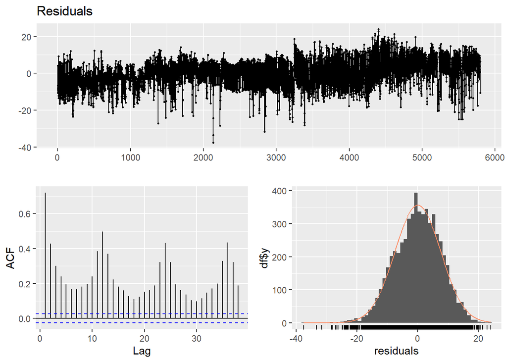

```
##
##  Breusch-Godfrey test for serial correlation of order up to 30
##
## data:  Residuals
## LM test = 3784.4, df = 30, p-value < 2.2e-16
```

```r
checkresiduals(model_avg_time)
```

####PACF plot of the residuals

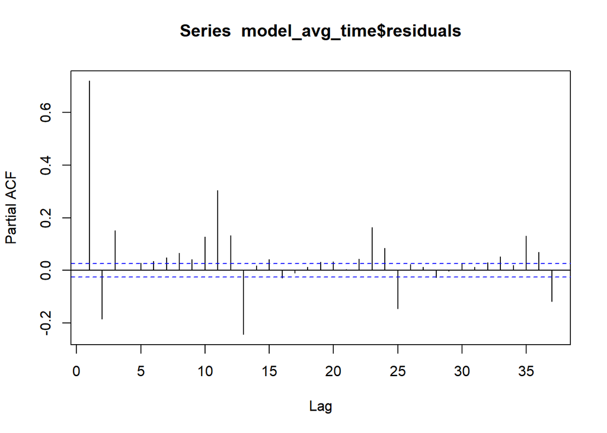

```r
pacf(model_avg_time$residuals) # pacf analysis of residuals
```

### c) Model with averaged data + time related regressors (hour and month) + lagged variables

```r
avgdata_lagged <- data.table(avgdata,lag1=c(NA,avgdata$production[1:length(avgdata$production)-1]),lag24=c(rep(NA,24),avgdata$production[1:(length(avgdata$production)-24)]))
#lag1 and lag 24 added

model_avg_time_lag = lm(production~.-date-hour-month+as.factor(month)+as.factor(hour)-production,avgdata_lagged[hour>=7 & hour <=18])
summary(model_avg_time_lag) #lag1 and lag24 added
```

```
##
## Call:
## lm(formula = production ~ . - date - hour - month + as.factor(month) +
##     as.factor(hour) - production, data = avgdata_lagged[hour >=
##     7 & hour <= 18])
##
## Residuals:
##     Min      1Q  Median      3Q     Max
## -37.018  -2.923   0.220   2.653  20.477
##
## Coefficients:
##                     Estimate Std. Error t value Pr(>|t|)
## (Intercept)        44.545689   5.491211   8.112 6.03e-16 ***
## cloud              -0.038337   0.004548  -8.429  < 2e-16 ***
## dswrf              -0.004815   0.001076  -4.477 7.72e-06 ***
## relhumidity        -0.020004   0.006981  -2.865 0.004179 **
## temp               -0.151312   0.021910  -6.906 5.52e-12 ***
## lag1                0.669408   0.009465  70.723  < 2e-16 ***
## lag24               0.202775   0.008668  23.393  < 2e-16 ***
## as.factor(month)2   0.226089   0.339870   0.665 0.505936
## as.factor(month)3   1.474105   0.346887   4.250 2.18e-05 ***
## as.factor(month)4   2.958493   0.429893   6.882 6.53e-12 ***
## as.factor(month)5   4.615201   0.497412   9.278  < 2e-16 ***
## as.factor(month)6   5.692746   0.561268  10.143  < 2e-16 ***
## as.factor(month)7   6.125629   0.619592   9.887  < 2e-16 ***
## as.factor(month)8   5.708472   0.620556   9.199  < 2e-16 ***
## as.factor(month)9   4.158449   0.531473   7.824 6.03e-15 ***
## as.factor(month)10  2.276172   0.459626   4.952 7.55e-07 ***
## as.factor(month)11  0.827053   0.414677   1.994 0.046150 *
## as.factor(month)12 -0.250424   0.373527  -0.670 0.502610
## as.factor(hour)8    4.118495   0.334108  12.327  < 2e-16 ***
## as.factor(hour)9    1.320566   0.373183   3.539 0.000405 ***
## as.factor(hour)10   1.390309   0.486524   2.858 0.004283 **
## as.factor(hour)11   1.052449   0.523774   2.009 0.044546 *
## as.factor(hour)12   1.292389   0.553554   2.335 0.019593 *
## as.factor(hour)13   1.379730   0.574526   2.402 0.016359 *
## as.factor(hour)14   0.860689   0.583254   1.476 0.140088
## as.factor(hour)15   0.129244   0.579745   0.223 0.823596
## as.factor(hour)16  -2.885437   0.517836  -5.572 2.63e-08 ***
## as.factor(hour)17  -7.737624   0.469613 -16.477  < 2e-16 ***
## as.factor(hour)18  -8.461100   0.423084 -19.999  < 2e-16 ***
## ---
## Signif. codes:  0 '***' 0.001 '**' 0.01 '*' 0.05 '.' 0.1 ' ' 1
##
## Residual standard error: 4.931 on 5755 degrees of freedom
##   (12 observations deleted due to missingness)
## Multiple R-squared:  0.8732, Adjusted R-squared:  0.8726
## F-statistic:  1416 on 28 and 5755 DF,  p-value: < 2.2e-16
```

```r
ForecastReportlm <- function(x_date) {
lm_vec <- rep(NA,12)
  dataf <- avgdata_lagged[date >= train_start & date < x_date & hour >=7 & hour <= 18]
  model1=lm(formula = production~.-date-hour-month+as.factor(month)+as.factor(hour)-production,dataf)
  test_data <- avgdata_lagged[date==as.Date(x_date)+1& hour >=7 & hour <= 18,c("date","hour","cloud",
                        "dswrf","relhumidity","month","temp","lag1","lag24")]
  lm_vec<- predict(model1,data.frame(test_data))
lm_vec <- c(rep(0,7),lm_vec,rep(0,5))
return(array(unlist(lm_vec)))
}
```

#### Residual plots of Model with averaged data + time related regressors (hour and month) + lagged variables

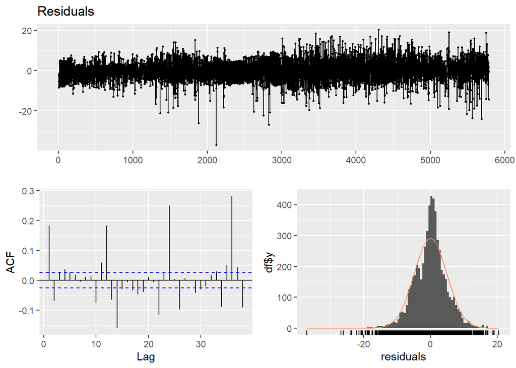

```
##
##  Breusch-Godfrey test for serial correlation of order up to 32
##
## data:  Residuals
## LM test = 996.53, df = 32, p-value < 2.2e-16
```

```r
checkresiduals(model_avg_time_lag)
```

Although adjusted R squared increased significantly, has a great value 0.8725 and correlation between residuals decreased there is still significant correlation between residuals. Also, residuals does not seem to have a constant variance (there is a significant increase after 3000). In short, addition of lagged variables leads to better model but does not solve the problems completely. However the fact that using lagged variables improve the model can be an indication of using arima and arima with regressors model would be helpful. The lagged production values does not fix the residuals completely but using them with lagged error variables can lead to a great improvement on the model.

### 2) ARIMA Models

Since regression models didn’t give a satisfactory result in terms of residuals, changing to an ARIMA model approach would be a good idea. Thus, first, data must be stationarized. As seen from the above analysis and below graph, daily series is not stationary since it has trend and seasonality. Therefore, it must be detrended and deseasonalized. For this reason, decomposition is done.

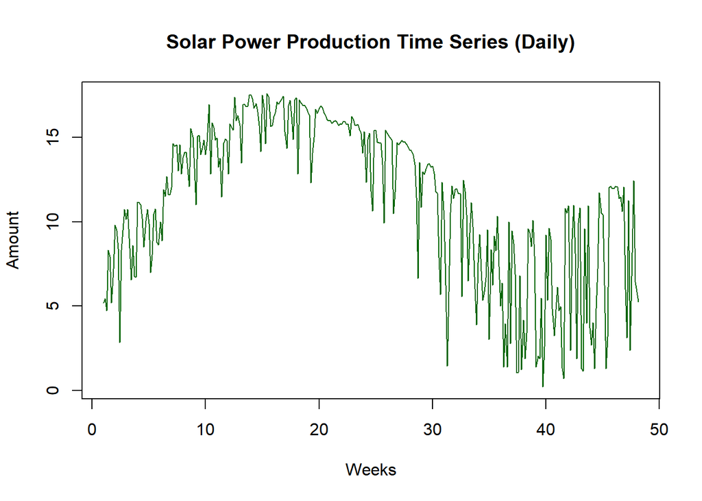

First data is deseasonalized. Resulting plot is shown below:

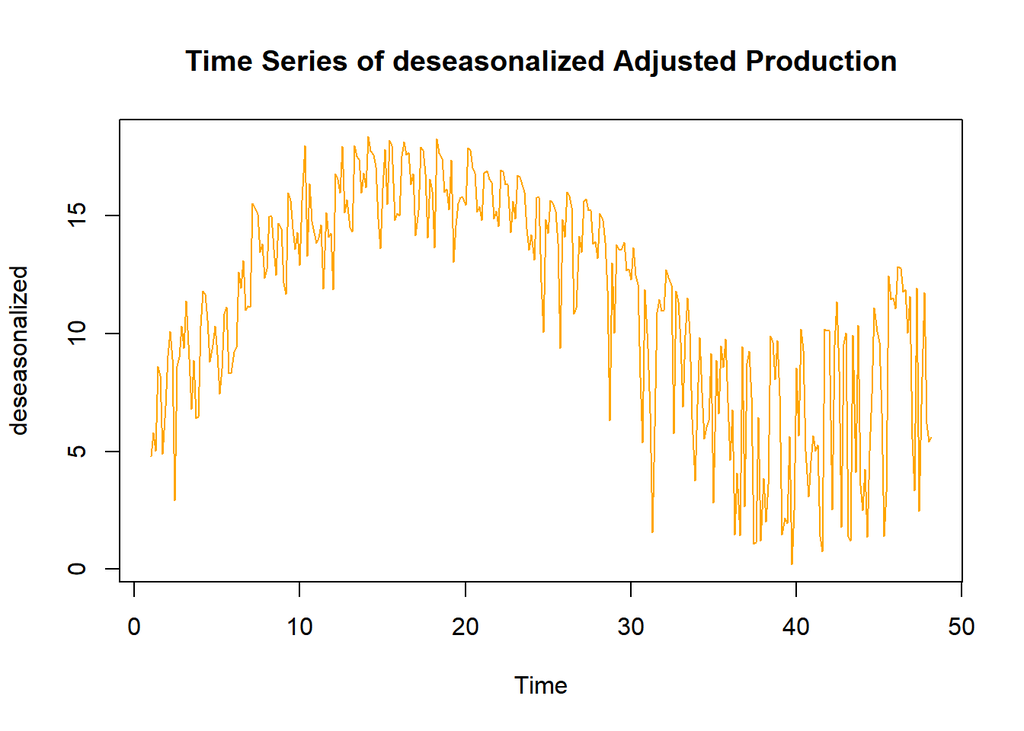

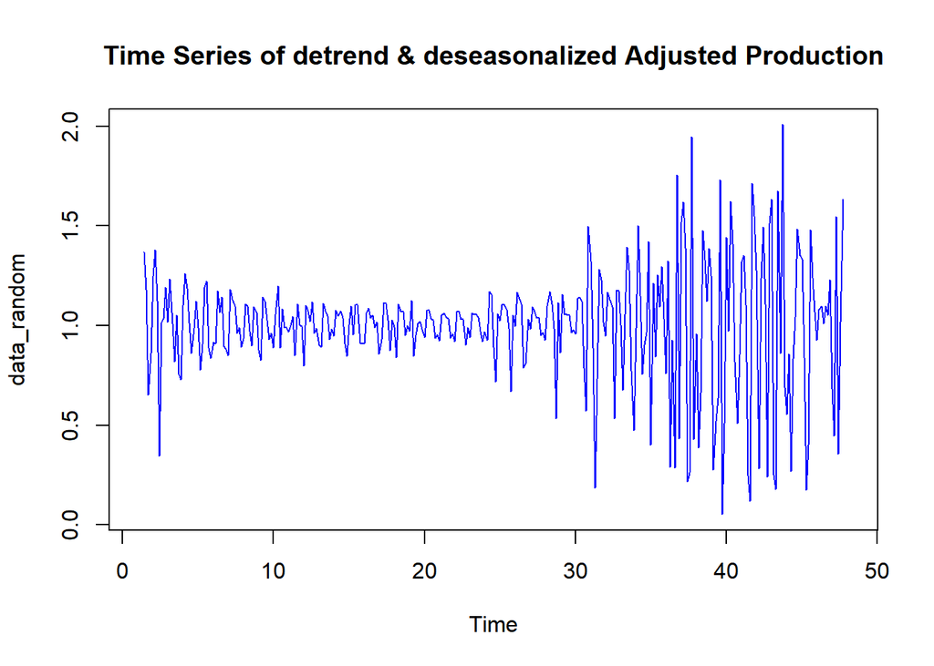

To see if the detrended and deseasonalized data is stationary, KPSS test is performed.

```r
a<- ur.kpss(data_random)
summary(a)
```

```
##
## #######################
## # KPSS Unit Root Test #
## #######################
##
## Test is of type: mu with 5 lags.
##
## Value of test-statistic is: 0.0769
##
## Critical value for a significance level of:
##                 10pct  5pct 2.5pct  1pct
## critical values 0.347 0.463  0.574 0.739
```

Test statistic is way smaller than 10 percent significance level, in other words, test statistic is not significantly large to reject the null hypothesis. Therefore, the null hyphothesis of the series being stationary is not rejected. This data can now be used to fit ARIMA models. To start the analysis of selecting parameters for ARIMA, ACF an PACF should be plotted.

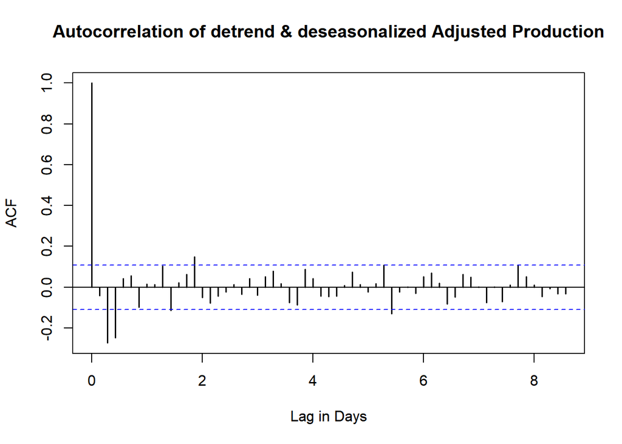

```r
plot(acf(na.omit(data_random),lag.max=60,plot=FALSE), main = "Autocorrelation of detrend & deseasonalized Adjusted Production",col="black", lwd=1.5, xlab="Lag in Days")
```

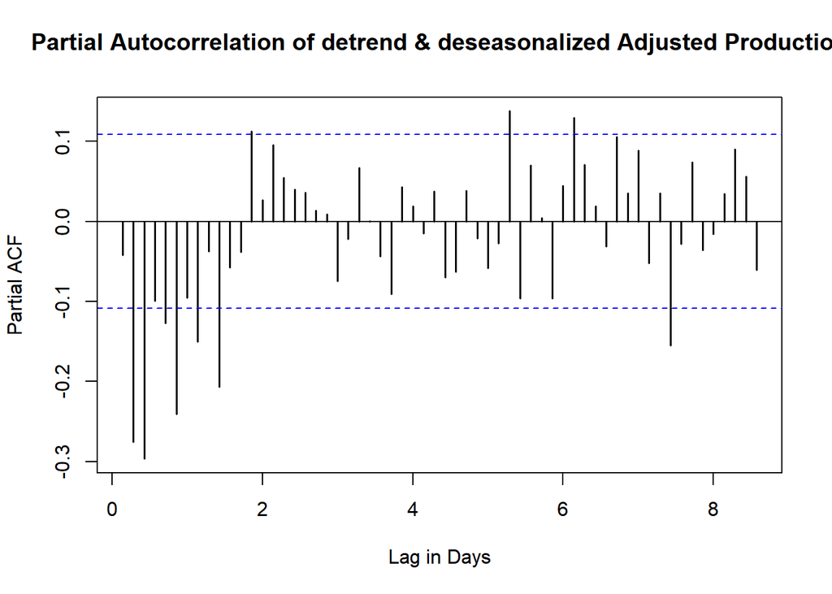

```r
plot(pacf(na.omit(data_random),lag.max=60,plot=FALSE), main = "Partial Autocorrelation of detrend & deseasonalized Adjusted Production",col="black", lwd=1.5, xlab="Lag in Days")
```

In this case, ACF and PACF plots don’t indicate some certain parameters. Therefore, first, it would be better to use auto.arima to come up with parameters. Since it is expected to come up with a prediction for every hours of the day, the best approach is to fit a model to each hour of a day. (i.e. a model for 01:00, a model for 02:00 etc.). Therefore, fitting an auto.arima model for each hour over the time would be a good starting point.

The evaluation of each model is done at the end of the report, using Weighted Mean Percentage Error as the performance measure.

### a) auto.arima model

```r
ForecastReportAutoAr <- function(x_date) {

arima_vec <- rep(NA,24)
BIC1<-rep(NA,24)
for (i in 0:23){
  dataf <- data[date >= train_start & date < x_date & hour == i,c("date","production")]
  dataf <- ts(dataf)
  fitted=auto.arima(dataf[,'production'],seasonal = T,trace=F)
  forecasted1=forecast(fitted,h=3)
  arima_vec[i+1]<-forecasted1$mean[3]
}
return(arima_vec)
}
```

Using a loop, an ARIMA model is fit to each hour of a day to forecast the production values for 2 days later.

### b)auto.arima model with 1 regressor

```r
ForecastReportArimax <- function(x_date) {
arima_vec_reg <- rep(NA,24)
for(i in 0:23) {
  dataf <- data[date >= train_start & date < x_date & hour == i,c("date","production")]
  dataf <- ts(dataf)
  regressor <- data[date >= train_start & date < x_date & hour == i,c("CLOUD_LOW_LAYER_36.25_33")]
  fitted_reg <- auto.arima(dataf[,'production'],xreg=data.matrix(regressor))
  regforecast <- w_weather[(date==x_date & hour==i) |(date==as.Date(x_date)+1 & hour==i)|date==as.Date(x_date)+2 & hour==i,c("CLOUD_LOW_LAYER_36.25_33")]
  forecasted2=forecast(fitted_reg,xreg=data.matrix(regforecast),h=3)
  arima_vec_reg[i+1] <- forecasted2$mean[3]
}
return(arima_vec_reg)
}
```

### c) auto.arima model with 3 regressors (ARIMAX3)

```r
ForecastReportArimax3<- function(x_date) {
arima_vec_reg2 <- rep(NA,24)
for(i in 0:23) {
  dataf <- avgdata[date >= train_start & date < x_date & hour == i,c("date","production")]
  dataf <- ts(dataf)
  regressor <- avgdata[date >= train_start & date < x_date & hour == i,c("cloud","temp","relhumidity")]
  fitted_reg <- auto.arima(dataf[,'production'],xreg=data.matrix(regressor))
  regforecast <- avgweather[(date==x_date & hour==i) |(date==as.Date(x_date)+1 & hour==i |date==as.Date(x_date)+2 & hour==i),c("cloud","temp","relhumidity")]
  forecasted2=forecast(fitted_reg,xreg=data.matrix(regforecast),h=3)
  arima_vec_reg2[i+1] <- forecasted2$mean[3]
}
return(arima_vec_reg2)
}
```

After seeing adding regressors indeed improves the model we added 3 regressors to the model, namely, cloud, temperature and humidity, which were also significant on the linear regression model. Since there are different values for different coordinates, we used the average of these values as regressors. Since this model gave satisfactorily good results, we used this model during the submission period.

### d)ARIMA (2,0,3)

After conducting further analysis, we developed an ARIMA model with parameters, p=2,d=0 and q=3. To fit this model, for each hour of the day, data was needed to be detrended and deseasonalized, thus, data is decomposed for each hour of the day, using a loop. Then, an arima model of ARIMA(2,0,3) is fit to each of the random components. Here, the random component is predicted and the trend and seasonality components which were previously decomposed from the data are added to the forecasted random component to come up with production values.

```r
ForecastReportArima <- function(x_date,Order) {
  Forecasted <- c()
  for (i in 7:19){
    df1<-data[date<=x_date]
    #Hour filtering
    df1=df1[df1$hour==i,c("date","production")]



    combined_data_decomp<-decompose(ts(df1$production,freq=7),type="multiplicative")


    noise<-combined_data_decomp$random
    trend<-combined_data_decomp$trend
    seasonality<-combined_data_decomp$seasonal

    nahead=3 # 2 days later prediction

    fitted=arima(noise,order=Order)

    predicted_noise <- forecast(fitted,h=nahead)$mean[3]
    last_trend_value <-tail(combined_data_decomp$trend[!is.na(combined_data_decomp$trend)],1)
    seasonality<-tail(combined_data_decomp$seasonal[!is.na(combined_data_decomp$seasonal)],1)

    ProdForecast<-predicted_noise*last_trend_value*seasonality
    Forecasted<-c(Forecasted,ProdForecast)

  }
  return(Forecasted)
}
```

## Results, Conclusions and Future Work

```
##            variable    n     mean       sd       CV      FBias MAPE     RMSE
## 1:   forecast_arima 2040 12.13835 14.68011 1.209399 0.03020355  NaN 5.057522
## 2:  forecast_arimax 2040 12.13835 14.68011 1.209399 0.00786250  NaN 5.904229
## 3: forecast_arimax3 2040 12.13835 14.68011 1.209399 0.01336478  NaN 5.827840
## 4:  forecast_autoar 2040 12.13835 14.68011 1.209399 0.02800247  NaN 5.545909
## 5:      forecast_lm 2040 12.13835 14.68011 1.209399 0.02099626  NaN 5.503611
## 6:            naive 2040 12.13835 14.68011 1.209399 0.00000000  NaN 0.000000
##         MAD      MADP     WMAPE
## 1: 2.713780 0.2235707 0.2235707
## 2: 2.991748 0.2464707 0.2464707
## 3: 3.068094 0.2527603 0.2527603
## 4: 2.997048 0.2469073 0.2469073
## 5: 2.938663 0.2420974 0.2420974
## 6: 0.000000 0.0000000 0.0000000
```

Overall, very limited data was available for this analysis, for example, since the plant hadn’t reached its full capacity in March 2021, the forecasts for March 2022 were worse than those of May 2022 since in May 2021, plant was at its capacity. Also, further analysis could be conducted on each model for the hours and check which models are contributing to the WMAPE the most.